# PA1_template

Muhammad Arshad khan

December 11, 2016

## 1-Loading Data

```r
myfile<-read.csv("activity.csv",header=TRUE, sep=",")
head(myfile)
```

```
##   steps       date interval
## 1    NA 2012-10-01        0
## 2    NA 2012-10-01        5
## 3    NA 2012-10-01       10
## 4    NA 2012-10-01       15
## 5    NA 2012-10-01       20
## 6    NA 2012-10-01       25
```

```r
vtot_Steps <-aggregate(steps~date,data=myfile,FUN=sum)
head(vtot_Steps)
```

```
##         date steps
## 1 2012-10-02   126
## 2 2012-10-03 11352
## 3 2012-10-04 12116
## 4 2012-10-05 13294
## 5 2012-10-06 15420
## 6 2012-10-07 11015
```

## 3-Make a histogram of the total number of steps taken each day

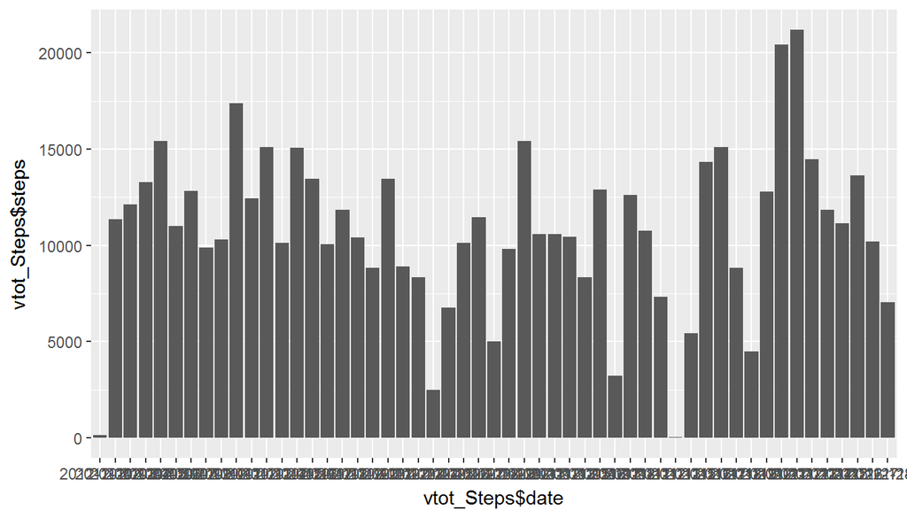

```r
library(ggplot2)
g <-ggplot(vtot_Steps,aes(x=vtot_Steps$date,y=vtot_Steps$steps))+geom_histogram(stat="identity")
g
```

```r
myFun <- function(x) {
  c(mean = mean(x), median = median(x)
  )
}
mymean<- aggregate(steps ~date , data=myfile[!is.null(myfile$steps),],FUN=myFun)
head(mymean)
```

```
##         date steps.mean steps.median
## 1 2012-10-02    0.43750      0.00000
## 2 2012-10-03   39.41667      0.00000
## 3 2012-10-04   42.06944      0.00000
## 4 2012-10-05   46.15972      0.00000
## 5 2012-10-06   53.54167      0.00000
## 6 2012-10-07   38.24653      0.00000
```

## 5-Make a time series plot (i.e. type = “l”) of the 5-minute interval (x-axis) and the average number of steps taken, averaged across all days (y-axis)

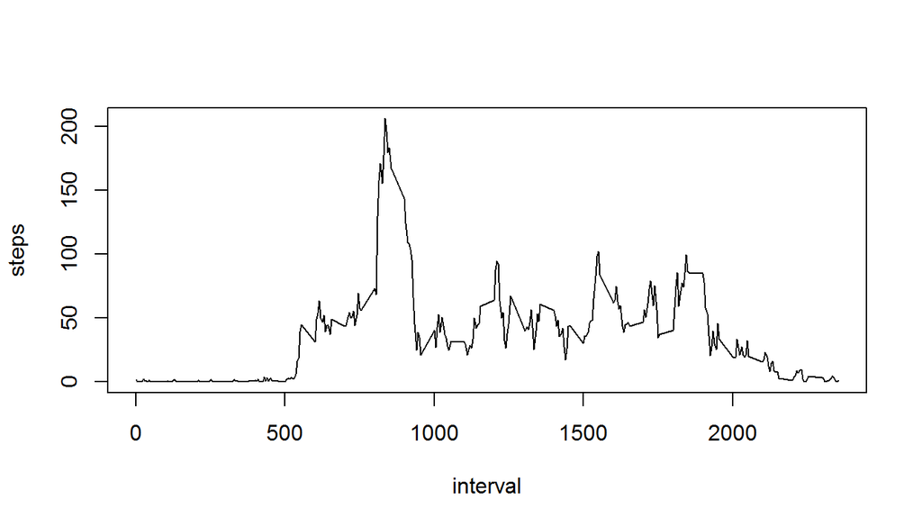

```r
mymean<- aggregate(steps ~ interval , data=myfile[!is.null(myfile$steps),],FUN=mean)
plot(steps ~ interval,data=mymean,type="l")
```

## 6-Which 5-minute interval, on average across all the days in the dataset, contains the maximum number of steps?

```r
maxinterval <-subset(mymean,steps ==max(mymean$steps))
print (maxinterval[,-2])
```

```
## [1] 835
```

## 7-Calculate and report the total number of missing values in the dataset (i.e. the total number of rows with NAs)

```r
total_null<-sum(is.na(myfile))
print (total_null)
```

```
## [1] 2304
```

## 8-Devise a strategy for filling in all of the missing values in the dataset.

```r
myfile[is.na(myfile)] <- 0
print (which (is.na(myfile)))
```

```
## integer(0)
```

## 9-Create a new dataset that is equal to the original dataset but with the missing data filled in.

```r
myfile <-read.csv("activity.csv",header = TRUE)
mynewfile <-myfile
mynewfile[is.na(mynewfile)] <- 0
```

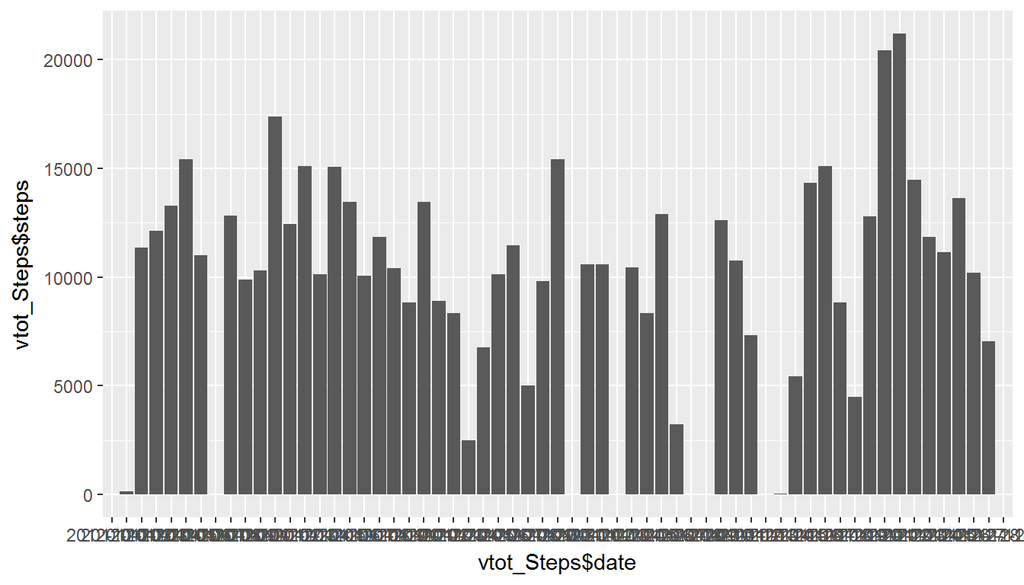

```r
vtot_Steps <-aggregate(steps~date,data=mynewfile,FUN=sum)
library(ggplot2)
g <-ggplot(vtot_Steps,aes(x=vtot_Steps$date,y=vtot_Steps$steps)) +geom_histogram(stat="identity")
g
```

```r
myweekend <- function(x) {
  if( x=="Friday" | x=="Saturday"){
    print("Weekend")}
  else {
    print("Weekday")
  }
}

mynewfile[,"weekday"]<-sapply(weekdays(as.Date(mynewfile$date,'%Y-%m-%d')),FUN=myweekend)
```

[output not shown]

```r
head(mynewfile)
```

```
##   steps       date interval weekday
## 1     0 2012-10-01        0 Weekday
## 2     0 2012-10-01        5 Weekday
## 3     0 2012-10-01       10 Weekday
## 4     0 2012-10-01       15 Weekday
## 5     0 2012-10-01       20 Weekday
## 6     0 2012-10-01       25 Weekday
```

## 12- Make a panel plot containing a time series plot (i.e. type = “l”) of the 5-minute interval (x-axis) and the average number of steps taken, averaged across all weekday days or weekend days (y-axis).

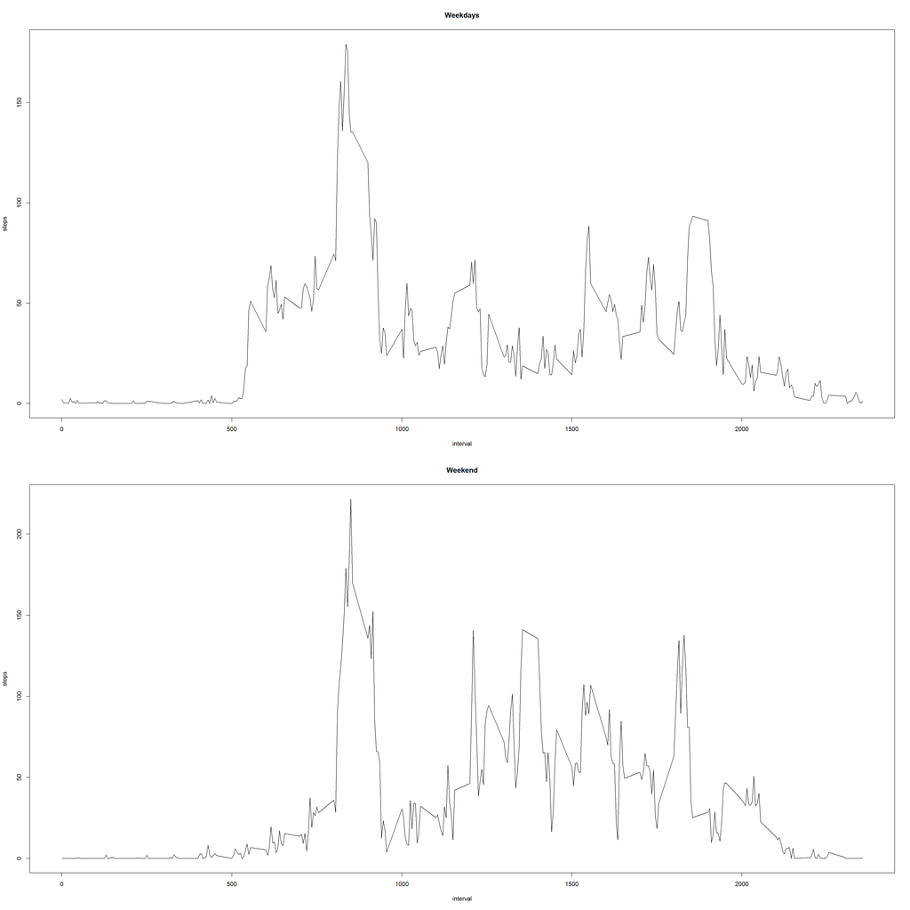

```r
mymeanweekdays<- aggregate(steps ~ interval , data=subset(mynewfile,mynewfile$weekday =="Weekday"),FUN=mean)
mymeanweekend<- aggregate(steps ~ interval , data=subset(mynewfile,mynewfile$weekday =="Weekend"),FUN=mean)
par(mfrow=c(2,1))
plot(steps ~ interval,data=mymeanweekdays,type="l",main="Weekdays")
plot(steps ~ interval,data=mymeanweekend,type="l",main="Weekend")
```